# Bulk RNAseq analysis

Alex Thiery

2023-01-20

### **R tutorial 1**

We will conduct bulk RNAseq analysis in R using [DESeq2](https://genomebiology.biomedcentral.com/articles/10.1186/s13059-014-0550-8) for data normalisation and differential expression testing.

This tutorial is focussed on the data objects used during DESeq2 differential expression analysis.

#### **Setup working environment**

```r
knitr::opts_knit$set(root.dir = '~/Downloads/')
```

Set working directory

```r
setwd('~/Downloads/')
```

First we need to install the required packages

```r
if (!require("tidyverse", quietly = TRUE))
    install.packages("tidyverse", repos = "http://cran.us.r-project.org")

if (!require("BiocManager", quietly = TRUE))
    install.packages("BiocManager", repos = "http://cran.us.r-project.org")

BiocManager::install(version = "3.16")
BiocManager::install("DESeq2")
BiocManager::install("apeglm")
```

Load packages

```r
library(DESeq2)
library(apeglm)
library(tidyverse)
```

It is useful to first set the paths where you want to save your outputs. I am adding these paths at the top of this script so that each of you can easily change the paths without causing any issues downstream

```r
output_path <- './output/'
dir.create(output_path, recursive = TRUE)
```

#### **Data pre-processing**

Read in transcript pseudo-counts from the alignment

```r
read_counts <- read.delim('./rnaseq_read_counts.tsv', stringsAsFactors = FALSE)
```

The first thing we need to do is check that all our gene names are unique - if not this can cause problems downstream if we want to be able to distinguish between two transcripts which have the same gene name. Therefore it is useful to first create a gene annotation dataframe with both unique gene ids and names before running any downstream analysis

#### Challenge 1: Check whether all gene names are unique, then check whether all gene ids are unique.

Tip - you can do this by checking if any elements of an array are duplicated

```r
any(duplicated(read_counts$gene_id))
```

```
## [1] FALSE
```

```r
any(duplicated(read_counts$gene_name))
```

```
## [1] TRUE
```

You can see here that gene ids are all unique, this is because gene ids are associated with unique genome co-ordinates. This isn’t necessarily the case with gene names!

We can make gene names unique by using adding an index and using “_” as a separator

```r
read_counts$gene_name <- make.unique(read_counts$gene_name, sep = "_")
```

Now that we have unique gene ids and gene names, we can create an annotations dataframe for safekeeping. This provides us a reference map to identify which gene id a specific gene of interest initially came from

```r
gene_annotations <- read_counts %>% dplyr::select(gene_id, gene_name)
write.csv(gene_annotations, paste0(output_path, "gene_annotations.csv"), row.names = F)
```

#### **Prepare transcript counts for DESeq2**

DESeq2 expects read counts to be integers by default. This RNAseq data was aligned using a pseudo-aligner which estimates transcript abundances without the need to explicitly assign reads to a specific transcript. This is can provide more accurate transcript abudance estimates when the sequencing read cannot distinguish between potential splice variants. More information regarding this is discussed in the introduction to RNAseq session.

We can convert the estimated transcript abundances to count data using the following command. Here we are selecting all the numeric columns of the dataframe and converting them to integers

```r
# In tidyverse
read_counts <- read_counts %>% mutate(across(where(is.numeric), as.integer))

# In base R
read_counts[,-c(1:2)] <- apply(read_counts[,-c(1:2)], 2, as.integer)
```

Before we load our data in to DESeq2, we first want to set the gene names as the rownames of the read_counts object, we then want to remove the gene_id and gene_annotation columns from our dataframe as DESeq2 expects a dataframe containing only count data.

```r
rownames(read_counts) <- read_counts$gene_name
read_counts[,1:2] <- NULL
head(read_counts)
```

```
##          GM12878_REP1 GM12878_REP2 H1_REP1 H1_REP2 K562_REP1 K562_REP2
## TSPAN6              8            0    8501    4508         3         2
## TNMD                0            0      70      30         0         0
## DPM1             4166         3646    1991     857      6371      8874
## SCYL3            1999         1638     633     434       995      1496
## C1orf112         1873         1664    3705    1777      2876      2994
## FGR              9870        11004     140     108         1         2
##          MCF7_REP1 MCF7_REP2
## TSPAN6        6564      4093
## TNMD             3         0
## DPM1         10980     10576
## SCYL3         2071      2134
## C1orf112      4209      3500
## FGR              0         4
```

Finally save the new readcounts output with unique gene ids, unique gene names and sample read counts as a CSV for future use

```r
write.csv(read_counts, paste0(output_path, "read_counts.csv"), row.names = TRUE)
```

#### **Initialise DESeq2 object**

Now that we have our read counts and gene annotation dataframe, we are ready to initialise our DESeq2 object.

DESeq2 requires sample metadata in order to know the groupings required for differential expression testing.

If we look at the column names of our dataset, we can see we have 4 conditions, each with two replicates: * GM12878 immortalized cell line * K562 immortalized cell line * MCF7 immortalized cell line * H1 hESC

```r
colnames(read_counts)
```

```
## [1] "GM12878_REP1" "GM12878_REP2" "H1_REP1"      "H1_REP2"      "K562_REP1"
## [6] "K562_REP2"    "MCF7_REP1"    "MCF7_REP2"
```

The sample metadata needs to be provided as a dataframe containing the sample names as rownames, an column titled ‘Group’ which specifies the condition. Additional columns specifying additional covariates can also be added if required.

Below I extract sample groups and replicate information from the sample names themselved.

```r
col_data <- data.frame(
  row.names = colnames(read_counts),
  Group = factor(sub("_.*", "", colnames(read_counts))),
  Replicate = sub(".*REP", "", colnames(read_counts))
)
```

Now it’s time to initialise the DESeq2 object.

The design argument is required to specify the sample groupings used for subsequent differential expression tests. In this example we are just wanting to look at genes differentially expressed between the different cell lines, so our experimental design is to look at gene expression as a function of ‘Group’. More complex formulas can be added here to account for additional covariates. See [DESeq2 documentation](http://bioconductor.org/packages/devel/bioc/vignettes/DESeq2/inst/doc/DESeq2.html#how-can-i-include-a-continuous-covariate-in-the-design-formula:~:text=and%20baySeq.-,Quick%20start,-Here%20we%20show) for more detail.

```r
deseq <- DESeqDataSetFromMatrix(read_counts, design = ~ Group, colData = col_data)
```

An important step in RNAseq preprocessing is to remove genes with very low expression. This helps to reduce the size of the dataset whilst also removing genes for which we have not captured meaningful biological variation.

#### Challenge 2: Filter the genes which have fewer than 5 counts in at least 2 samples.

```r
deseq <- deseq[rowSums(counts(deseq) > 5) >= 2, ]
```

Next I set the reference level of the Group column to GM12878. This reference level is your control sample. Subsequent pairwise differential expression test compare different conditions relative to this control.

```r
deseq$Group <- relevel(deseq$Group, ref = "GM12878")
```

#### **Run DESeq2**

The standard differential expression analysis steps are wrapped into a single function, DESeq.

During this step, DESeq2 will: 1) Normalise the data using the medians of ratios method, which effectively corrects for differences in sequencing depth and RNA composition between samples. 2) Calculate gene dispersion estimates 3) Fit generalised linear models of gene expression for each gene

```r
deseq <- DESeq(deseq)
```

Next, we want to visualise the overall relationship between different samples and replicates. For this, we need to first use DESeq2’s *rlog* or *vst* functions to transform the data to prevent the highest expressed genes from dominating. This is used for applications other than differential testing, for example when clustering the samples.

```r
rld <- rlog(deseq)
```

Next, we can run PCA analysis for dimensionality reduction in order to visualise the relationship between samples in 2-dimensions.

You can see here from the output that for each condition, there are two replicates which cluster very closely together. This shows that their is low variability between biological replicates, and therefore that most of the variation observed is due to the sample condition.

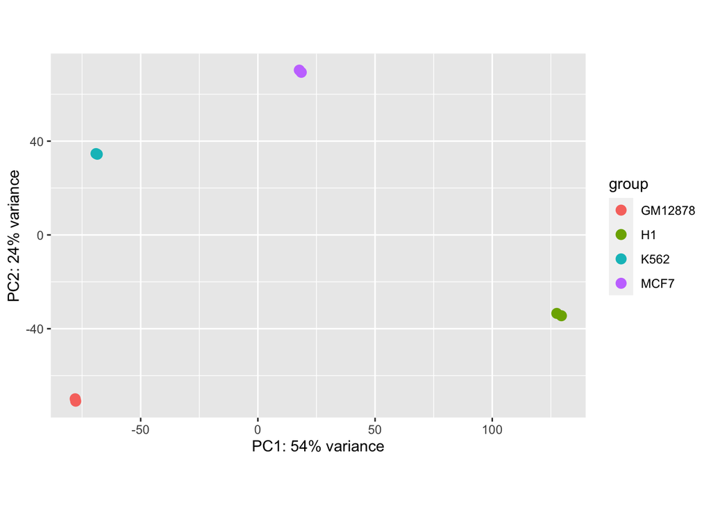

```r
plotPCA(rld, intgroup = "Group")
```

#### DESeq2 under the hood

The size factors shown below are the values for which gene expression in each sample is scaled for in order to account for sequencing depth and RNA composition.

```r
sizeFactors(deseq)
```

```
## GM12878_REP1 GM12878_REP2      H1_REP1      H1_REP2    K562_REP1    K562_REP2
##    0.9465474    0.9180849    1.0736303    0.8794741    0.9498253    1.1681232
##    MCF7_REP1    MCF7_REP2
##    1.1890836    1.2208435
```

After read counts have been normalised, DESeq2 calculates gene dispersion estimates. Gene dispersion represents gene variance adjusted for gene expression level.

A more detailed explanation of how gene dispersion is calculated can be found in the ‘[Introduction to DESeq2](https://moodle.learninghub.kingshealthpartners.org/course/view.php?id=353&section=5)’ section of this course.

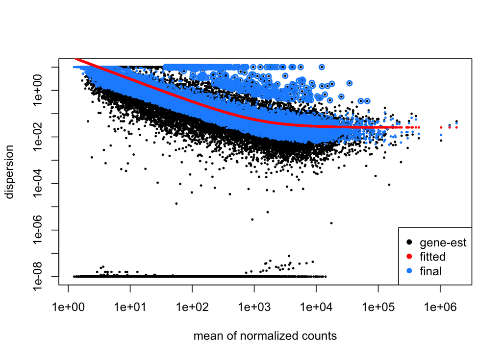

```r
plotDispEsts(deseq)
```

#### Differential expression

Results tables of specific pairwise differential expression tests can then be retrieved using the *results* function. This extracts a results table with log2 fold changes, p-values and adjusted p-values.

```r
res <- results(deseq)
res
```

```
## log2 fold change (MLE): Group MCF7 vs GM12878
## Wald test p-value: Group MCF7 vs GM12878
## DataFrame with 23907 rows and 6 columns
##                baseMean log2FoldChange     lfcSE       stat      pvalue
##               <numeric>      <numeric> <numeric>  <numeric>   <numeric>
## TSPAN6        2741.2407      10.019376  0.656445  15.263085 1.34725e-52
## TNMD            12.7292       2.673264  3.098093   0.862874 3.88207e-01
## DPM1          5425.3358       1.095957  0.302968   3.617401 2.97576e-04
## SCYL3         1349.6246      -0.158969  0.216310  -0.734911 4.62394e-01
## C1orf112      2657.5319       0.756858  0.295680   2.559721 1.04756e-02
## ...                 ...            ...       ...        ...         ...
## RP11-225H22.7  10.89140     -0.1569744  1.980790 -0.0792484    0.936835
## RP11-731C17.2 117.93312      0.3625002  0.467333  0.7756779    0.437939
## RP11-114I8.4   19.58589     -0.0552206  0.962785 -0.0573551    0.954262
## RP11-180C16.1  29.72969      1.6454726  1.585708  1.0376893    0.299415
## AP000230.1      9.45268      4.9878052  2.570318  1.9405404    0.052314
##                      padj
##                 <numeric>
## TSPAN6        3.81905e-51
## TNMD          4.93693e-01
## DPM1          7.76068e-04
## SCYL3         5.69233e-01
## C1orf112      2.11197e-02
## ...                   ...
## RP11-225H22.7   0.9550389
## RP11-731C17.2   0.5450525
## RP11-114I8.4    0.9648812
## RP11-180C16.1   0.3973945
## AP000230.1      0.0896097
```

```r
resultsNames(deseq)
```

```
## [1] "Intercept"             "Group_H1_vs_GM12878"   "Group_K562_vs_GM12878"
## [4] "Group_MCF7_vs_GM12878"
```

By default, DESeq2 will compare the last variable in the design condition to the reference level previously set using the *relevel* function.

```r
res <- results(deseq, name=c("Group_K562_vs_GM12878"))
res
```

```
## log2 fold change (MLE): Group K562 vs GM12878
## Wald test p-value: Group K562 vs GM12878
## DataFrame with 23907 rows and 6 columns
##                baseMean log2FoldChange     lfcSE       stat      pvalue
##               <numeric>      <numeric> <numeric>  <numeric>   <numeric>
## TSPAN6        2741.2407      -0.848875  0.919535 -0.9231570  0.35592541
## TNMD            12.7292      -0.176310  3.315604 -0.0531757  0.95759189
## DPM1          5425.3358       0.772734  0.303038  2.5499565  0.01077364
## SCYL3         1349.6246      -0.742271  0.217135 -3.4184755  0.00062973
## C1orf112      2657.5319       0.560327  0.295825  1.8941169  0.05820950
## ...                 ...            ...       ...        ...         ...
## RP11-225H22.7  10.89140       1.297177  1.958847  0.6622143 0.507833901
## RP11-731C17.2 117.93312      -0.154885  0.471114 -0.3287643 0.742333865
## RP11-114I8.4   19.58589      -4.577819  1.259171 -3.6355813 0.000277355
## RP11-180C16.1  29.72969      -1.258169  1.734316 -0.7254554 0.468172671
## AP000230.1      9.45268      -0.176301  2.924018 -0.0602942 0.951921322
##                      padj
##                 <numeric>
## TSPAN6         0.49033398
## TNMD           0.97918104
## DPM1           0.02413278
## SCYL3          0.00179878
## C1orf112       0.10646724
## ...                   ...
## RP11-225H22.7 0.650213007
## RP11-731C17.2 0.869382509
## RP11-114I8.4  0.000838302
## RP11-180C16.1 0.610036741
## AP000230.1    0.979181037
```

If you would like to carry out pairwise tests between conditions other than your control, you can change the reference sample using *relevel*. Here, let’s set the reference level to the hESC line.

```r
deseq$Group <- relevel(deseq$Group, ref = "H1")
deseq <- DESeq(deseq)
```

```
## found already estimated dispersions, replacing these
```

```r
resultsNames(deseq)
```

```
## [1] "Intercept"           "Group_GM12878_vs_H1" "Group_K562_vs_H1"
## [4] "Group_MCF7_vs_H1"
```

```r
res <- results(deseq, name=c("Group_MCF7_vs_H1"))
res
```

```
## log2 fold change (MLE): Group MCF7 vs H1
## Wald test p-value: Group MCF7 vs H1
## DataFrame with 23907 rows and 6 columns
##                baseMean log2FoldChange     lfcSE      stat      pvalue
##               <numeric>      <numeric> <numeric> <numeric>   <numeric>
## TSPAN6        2741.2407      -0.555966  0.412236 -1.348657 1.77447e-01
## TNMD            12.7292      -5.302117  2.745660 -1.931090 5.34719e-02
## DPM1          5425.3358       2.660662  0.303782  8.758462 1.97933e-18
## SCYL3         1349.6246       1.686946  0.219549  7.683701 1.54558e-14
## C1orf112      2657.5319       0.227284  0.295349  0.769544 4.41571e-01
## ...                 ...            ...       ...       ...         ...
## RP11-225H22.7  10.89140      -1.412148  1.954633 -0.722462   0.4700103
## RP11-731C17.2 117.93312       0.919545  0.471394  1.950692   0.0510937
## RP11-114I8.4   19.58589       1.834555  1.005062  1.825315   0.0679535
## RP11-180C16.1  29.72969      -2.911190  1.503947 -1.935700   0.0529045
## AP000230.1      9.45268      -2.333059  2.135275 -1.092627   0.2745576
##                      padj
##                 <numeric>
## TSPAN6        2.39226e-01
## TNMD          8.29640e-02
## DPM1          1.43578e-17
## SCYL3         8.64172e-14
## C1orf112      5.26192e-01
## ...                   ...
## RP11-225H22.7   0.5538388
## RP11-731C17.2   0.0796969
## RP11-114I8.4    0.1028460
## RP11-180C16.1   0.0822025
## AP000230.1      0.3505693
```

We use the DESeq2 function lfcShrink in order to calculate more accurate log2FC estimates. This uses information across all genes to shrink LFC when a gene has low counts or high dispersion values.

```r
res <- lfcShrink(deseq, coef=c("Group_MCF7_vs_H1"), type = 'apeglm')
```

```
## using 'apeglm' for LFC shrinkage. If used in published research, please cite:
##     Zhu, A., Ibrahim, J.G., Love, M.I. (2018) Heavy-tailed prior distributions for
##     sequence count data: removing the noise and preserving large differences.
##     Bioinformatics. https://doi.org/10.1093/bioinformatics/bty895
```

```r
res
```

```
## log2 fold change (MAP): Group MCF7 vs H1
## Wald test p-value: Group MCF7 vs H1
## DataFrame with 23907 rows and 5 columns
##                baseMean log2FoldChange     lfcSE      pvalue        padj
##               <numeric>      <numeric> <numeric>   <numeric>   <numeric>
## TSPAN6        2741.2407      -0.479361  0.389605 1.77447e-01 2.39226e-01
## TNMD            12.7292      -0.440143  1.152660 5.34719e-02 8.29640e-02
## DPM1          5425.3358       2.609041  0.305479 1.97933e-18 1.43578e-17
## SCYL3         1349.6246       1.653791  0.219781 1.54558e-14 8.64172e-14
## C1orf112      2657.5319       0.211374  0.284256 4.41571e-01 5.26192e-01
## ...                 ...            ...       ...         ...         ...
## RP11-225H22.7  10.89140      -0.300488  0.963276   0.4700103   0.5538388
## RP11-731C17.2 117.93312       0.790752  0.451886   0.0510937   0.0796969
## RP11-114I8.4   19.58589       1.152023  0.956407   0.0679535   0.1028460
## RP11-180C16.1  29.72969      -1.191238  1.511991   0.0529045   0.0822025
## AP000230.1      9.45268      -0.407383  1.045429   0.2745576   0.3505693
```

#### Challenge 3: Identify which gene has the highest log2FC when comparing MCF7 vs K562.

First you need to relevel the deseq object so you perform the correct test (MCF7 vs K562), then you need to reorder the results to extract the highest LogFC gene.

```r
deseq_temp <- deseq
deseq_temp$Group <- relevel(deseq_temp$Group, ref = "K562")
deseq_temp <- DESeq(deseq_temp)
```

```
## found already estimated dispersions, replacing these
```

```r
resultsNames(deseq_temp)
```

```
## [1] "Intercept"             "Group_H1_vs_K562"      "Group_GM12878_vs_K562"
## [4] "Group_MCF7_vs_K562"
```

```r
res <- results(deseq_temp, name=c("Group_MCF7_vs_K562"))
head(res[order(res$log2FoldChange, decreasing = TRUE),])
```

```
## log2 fold change (MLE): Group MCF7 vs K562
## Wald test p-value: Group MCF7 vs K562
## DataFrame with 6 rows and 6 columns
##             baseMean log2FoldChange     lfcSE      stat      pvalue        padj
##            <numeric>      <numeric> <numeric> <numeric>   <numeric>   <numeric>
## AC034102.1   729.652        25.7016   4.78471   5.37161 7.80382e-08 2.83843e-07
## SLC5A3       968.722        24.0486   3.47037   6.92970 4.21738e-12 2.23102e-11
## RNY3         135.670        22.5500   4.78505   4.71259 2.44582e-06 7.66467e-06
## SPTSSB     31091.191        19.4287   1.45906  13.31590 1.87115e-40 4.65358e-39
## GFRA1      19138.744        18.7334   1.47763  12.67800 7.83048e-37 1.67702e-35
## KRT80      13632.379        18.2519   1.45798  12.51861 5.90625e-36 1.22386e-34
```

A summary table of the results for a given adjusted p-value threshold (alpha) can also easily be printed.

```r
summary(res, alpha = 0.05)
```

```
##
## out of 23907 with nonzero total read count
## adjusted p-value < 0.05
## LFC > 0 (up)       : 7461, 31%
## LFC < 0 (down)     : 5783, 24%
## outliers [1]       : 0, 0%
## low counts [2]     : 927, 3.9%
## (mean count < 3)
## [1] see 'cooksCutoff' argument of ?results
## [2] see 'independentFiltering' argument of ?results
```

We can save the output deseq object for our next session on visualisation with heatmaps and volcano plots

```r
saveRDS(deseq, paste0(output_path, 'deseq_output.RDS'))
```